# Data Visualization Workshop: Activity 2

28 May 2025

## Part a

Type in code that will load the tidyverse, which contains ggplot2.

```r
library(tidyverse)
```

## Part b

We are going to use the gss_cat data set that was loaded with the tidyverse. Using `ggplot()` and `geom_bar()`, create a bar plot of the marital variable from the gss_catdata set.

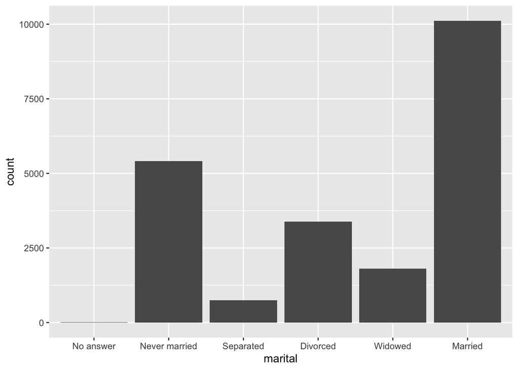

```r
ggplot(gss_cat, aes(x = marital)) + # Put the proper variable in the aes() function
  geom_bar() # Complete this line
```

## Part c

Copy and paste your code from part b. In the geom_bar() function, use the fill option to change the fill color of of bars to one of your choice (except don’t choose black).

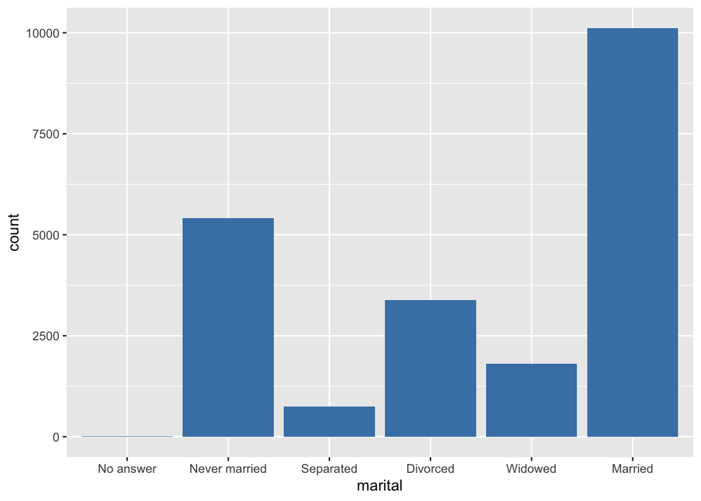

```r
ggplot(gss_cat, aes(x = marital)) + # Put the proper variable in the aes() function
  geom_bar(fill = "steelblue") # Complete this line
```

## Part d

Some fill colors lack contrast with the background. Copy and paste your code from part c and then add color = “black” inside the geom_bar() function. Comment on what that did.

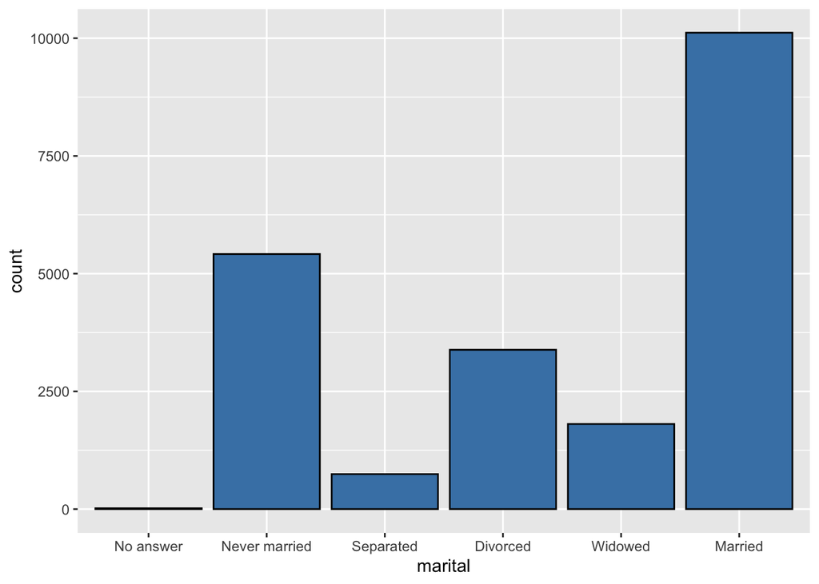

```r
ggplot(gss_cat, aes(x = marital)) + # Put the proper variable in the aes() function
  geom_bar(fill = "steelblue", color = "black") # Complete this line
```

That put a black border around the bars.

## Part e

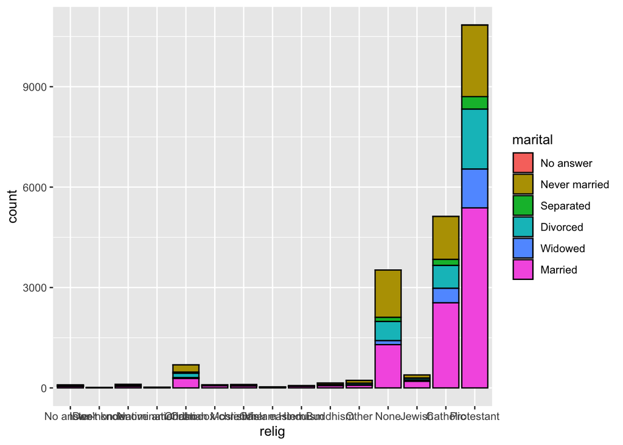

```r
ggplot(gss_cat, aes(x = relig, fill = marital)) + # Complete the aes() function
  geom_bar(color = "black")
```

## Part f

There are a couple issues with that plot in part e. First, the plot is dominated by the protestant, catholic, and none categories. Let’s adjust each bar so the heights are standardized by putting `position = "fill"` in the `geom_bar()` function. Second, the x-axis labels overlap. We can adjust the angle option in element_text for the `axis.text.x` in the `theme()` function. Putting `hjust = 1` might also help.

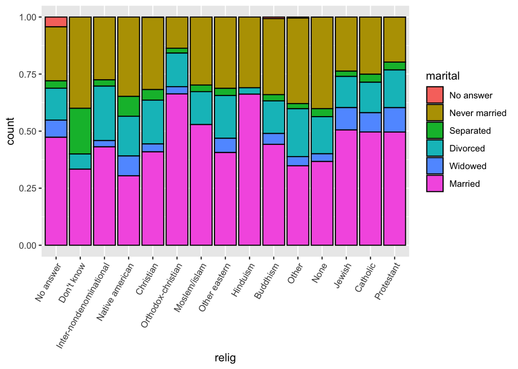

```r
ggplot(gss_cat, aes(x = relig, fill = marital)) + # Complete the aes() function
  geom_bar(color = "black", position = "fill") + # Add position = "fill" here
  theme(axis.text.x = element_text(angle = 60, hjust = 1)) # Add angle in here to swivel the category labels
```

## Part g

Now let’s move onto a histogram. Make a histogram for the tvhours variable in the `gss_cat` data set.

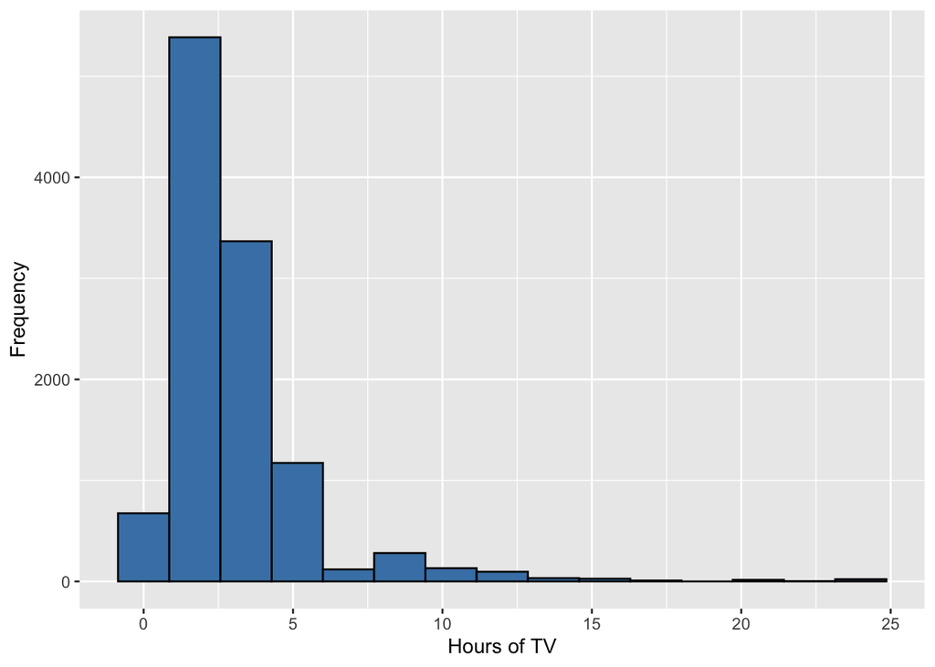

```r
ggplot(gss_cat, aes(x = tvhours)) + # Fill in the right argument in the aes() function
  geom_histogram(color = "black", fill = "steelblue", bins = 15) +
  # Fill in the color and fill options to make it look
  #   good. Also put bins = 15.
  labs(x = "Hours of TV", y = "Frequency")   # Fill in the labels for the x and y axes. Make the
```

```r
#   label for the x-axis be "Hours of TV" and the label
#   for the y-axis be "Frequency"
```

## Part h

Make a vertical boxplot of `tvhours`, so you should have `y = tvhours` in the `aes()` function. Change the fill color of it to one of your choice.

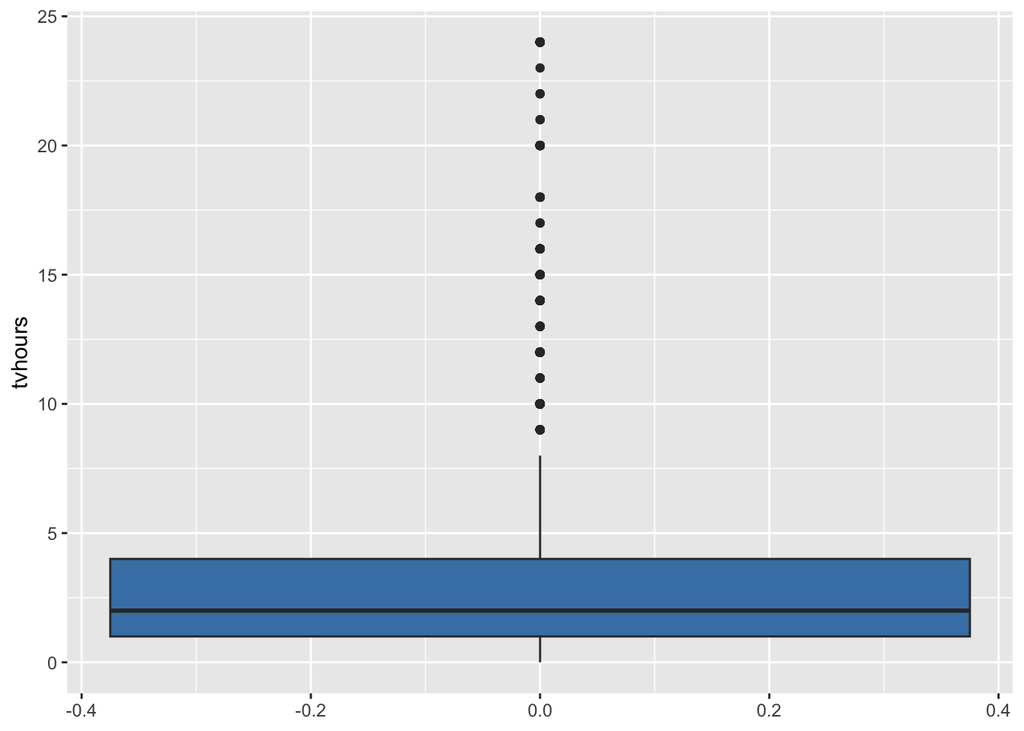

```r
ggplot(gss_cat, aes(y = tvhours)) +
  geom_boxplot(fill = "steelblue")
```

## Part i

Make side-by-side boxplots for comparing tvhours for the different marital categories. You can do this by putting `x = marital` and `y = tvhours` in the `aes()` function. Then fill in the rest of the code here. Change the fill color to one you like and put appropriate labels.

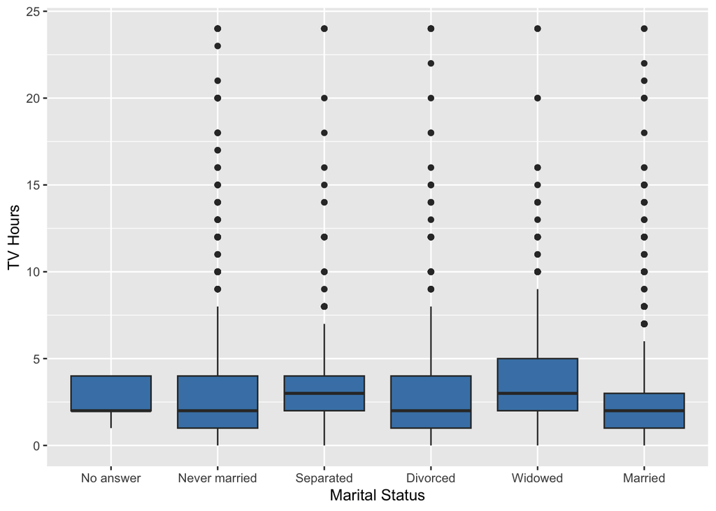

```r
ggplot(gss_cat, aes(x = marital, y = tvhours)) +
  geom_boxplot(fill = "steelblue") +
  labs(x = "Marital Status", y = "TV Hours")
```

## Part j

Finally, make a scatter plot with age on the x-axis and tvhours on the y-axis. - Change the color based on the marital variable. - Change the shape to something other than circles. - Change the background theme to something other than gray. - Put some labels, give a title, and change the text size to be bigger. - Then add geom_smooth(method = “lm”) to draw the lines of best fit. Does there seem to be a relationship between the variables?

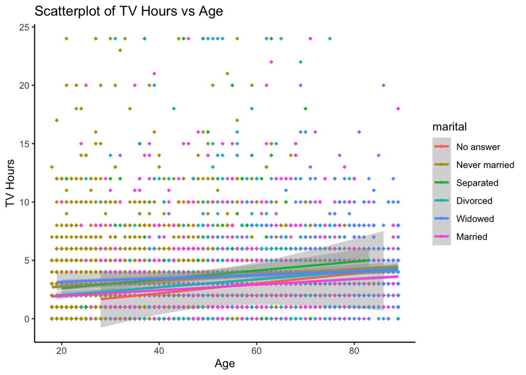

```r
ggplot(gss_cat, aes(x = age, y = tvhours, color = marital)) + # Put the aes() function in ggplot
  geom_point(shape = 18) + # Finish this line. Change the shape here.
  theme_classic() + # Finish this line
  labs(x = "Age", y = "TV Hours", title = "Scatterplot of TV Hours vs Age") + # Add axis labels and a title
  geom_smooth(method = "lm") # Change the method in this function
```

The relationship between age and tv hours seems to be very weak, but positive.

Based on the lines of best fit, those who are married seem to watch the least amount of TV. For those under the age of about 45, widowed people tend to watch the most TV while for those over 45, separated watch the most.